# Flights Data Exploration

### What is the structure of your dataset?

In this project, i am using six(6) datasets for three(3) years 2006 and 2008. There are 16,984,354 flight observations with 29 features in total.

i have 3 sub-dataset:

> cleaned_cancel :all rows whose flight were cancelled with a total of 347,124 observation

> cleaned_delay : all rows whose departure time were delayed by at least one minute with a total of 6,964,015

### What is/are the main feature(s) of interest in your dataset?

I am interested in knowing the most used carriers, destinations ,preferrred dayofweek , timeofday, with lesser cancellation or delays and the top reason for cancellation distributed in years

### What features in the dataset do you think will help support your investigation into your feature(s) of interest?

Destination will help me ascertain what destination is frequently used and which destination record high number of cancellation or delay. DayOfWeek, will answer my question of period with the least cancellation or delays. uniquecarrier will help me ascertain carrier with high number of cancellation or delay, same with cancellationcode and crsdeptime.

## Univariate Exploration

```python
#describe the joined table
cleaned.describe()
```

|  | year | month | dayofweek | deptime | crsdeptime | arrtime | crsarrtime | airtime | arrdelay | depdelay | cancelled | diverted | carrierdelay | weatherdelay | nasdelay | securitydelay | lateaircraftdelay |
| --- | --- | --- | --- | --- | --- | --- | --- | --- | --- | --- | --- | --- | --- | --- | --- | --- | --- |
| count | 1.698435e+07 | 1.698435e+07 | 1.698435e+07 | 1.663723e+07 | 1.698435e+07 | 1.659821e+07 | 1.698435e+07 | 1.659821e+07 | 1.659821e+07 | 1.663723e+07 | 1.698435e+07 | 1.698435e+07 | 1.517972e+07 | 1.517972e+07 | 1.517972e+07 | 1.517972e+07 | 1.517972e+07 |
| mean | 2.006720e+03 | 5.970939e+00 | 3.937186e+00 | 1.339827e+03 | 1.331206e+03 | 1.484658e+03 | 1.495739e+03 | 1.031516e+02 | 9.566669e+00 | 1.085349e+01 | 2.043787e-02 | 2.297350e-03 | 4.102358e+00 | 8.110254e-01 | 4.167233e+00 | 2.933598e-02 | 5.435765e+00 |
| std | 6.948869e-01 | 3.496356e+00 | 1.990502e+00 | 4.785037e+02 | 4.639545e+02 | 5.046566e+02 | 4.807802e+02 | 7.174682e+01 | 3.823369e+01 | 3.511446e+01 | 1.414926e-01 | 4.787559e-02 | 2.113781e+01 | 9.679868e+00 | 1.688402e+01 | 1.209718e+00 | 2.179563e+01 |
| min | 2.006000e+03 | 1.000000e+00 | 1.000000e+00 | 1.000000e+00 | 0.000000e+00 | 1.000000e+00 | 0.000000e+00 | -1.425000e+03 | -5.920000e+02 | -1.200000e+03 | 0.000000e+00 | 0.000000e+00 | 0.000000e+00 | 0.000000e+00 | 0.000000e+00 | 0.000000e+00 | 0.000000e+00 |
| 25% | 2.006000e+03 | 3.000000e+00 | 2.000000e+00 | 9.300000e+02 | 9.300000e+02 | 1.109000e+03 | 1.115000e+03 | 5.500000e+01 | -9.000000e+00 | -4.000000e+00 | 0.000000e+00 | 0.000000e+00 | 0.000000e+00 | 0.000000e+00 | 0.000000e+00 | 0.000000e+00 | 0.000000e+00 |
| 50% | 2.007000e+03 | 6.000000e+00 | 4.000000e+00 | 1.329000e+03 | 1.324000e+03 | 1.515000e+03 | 1.520000e+03 | 8.500000e+01 | -1.000000e+00 | 0.000000e+00 | 0.000000e+00 | 0.000000e+00 | 0.000000e+00 | 0.000000e+00 | 0.000000e+00 | 0.000000e+00 | 0.000000e+00 |
| 75% | 2.007000e+03 | 9.000000e+00 | 6.000000e+00 | 1.732000e+03 | 1.720000e+03 | 1.911000e+03 | 1.907000e+03 | 1.320000e+02 | 1.400000e+01 | 1.000000e+01 | 0.000000e+00 | 0.000000e+00 | 0.000000e+00 | 0.000000e+00 | 0.000000e+00 | 0.000000e+00 | 0.000000e+00 |
| max | 2.008000e+03 | 1.200000e+01 | 7.000000e+00 | 2.930000e+03 | 2.359000e+03 | 2.955000e+03 | 2.400000e+03 | 1.958000e+03 | 2.598000e+03 | 2.601000e+03 | 1.000000e+00 | 1.000000e+00 | 2.580000e+03 | 1.429000e+03 | 1.392000e+03 | 3.920000e+02 | 1.366000e+03 |

## What is the peak Cancellationcode?

```python
#replacing all abbreviated letter to full name
cleaned.cancellationcode = cleaned.cancellationcode.replace({'A':'Carrier','B':'Weather','C':'Nas','D':'Security'})
base_color = sns.color_palette()[0]
```

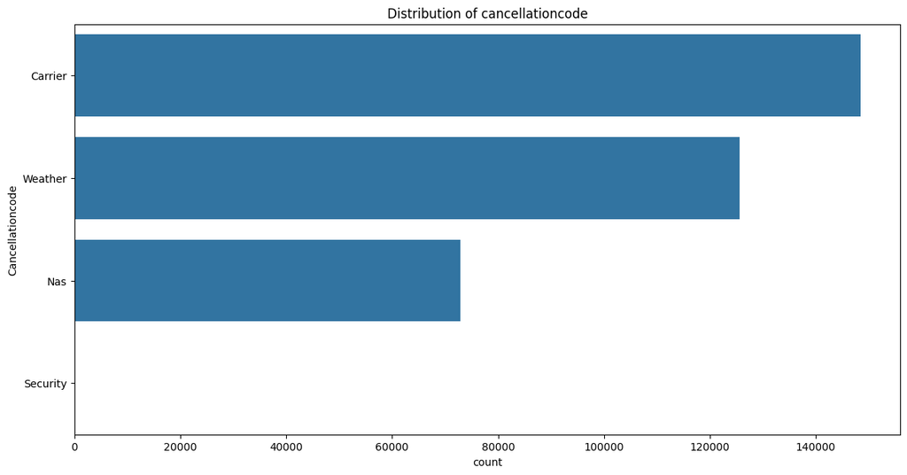

```python
plt.figure(figsize=(14,7))
plot_cancel = cleaned.cancellationcode.value_counts()
plot_cancel_index = plot_cancel.index
plot_cancel_value = plot_cancel.values
sns.barplot(y= plot_cancel_index,x=plot_cancel_value, color=base_color)
plt.title('Distribution of cancellationcode')
plt.ylabel('Cancellationcode')
plt.xlabel('count');
```

This plot helped me displayed the distribution of cancellation cause. Carrier had the highest cancellation cause, followed by weather and Nasdelay , i will investigate it further in next section

### The Distribution of flights by dayofweek

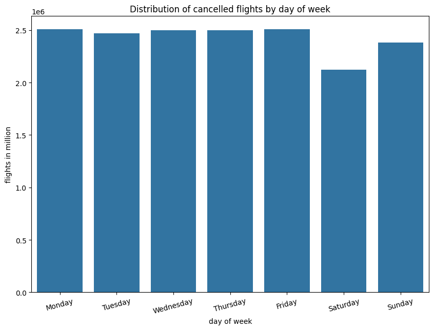

```python
#create a label of day of the week
plt.figure(figsize=(10,7))
label = ['Monday','Tuesday','Wednesday','Thursday','Friday','Saturday','Sunday']
#create a barplot
sns.countplot(data=cleaned, x='dayofweek',color=base_color)#order=label
plt.xticks(rotation=15,ticks=[0,1,2,3,4,5,6],labels=label)
plt.ylabel('flights in million')
plt.xlabel('day of week')
plt.title('Distribution of cancelled flights by day of week');
```

This barplot shows that Weekend(saturday and sunday) had little drop in flights during weekend

#### Distribution of flights by uniquecarrier code

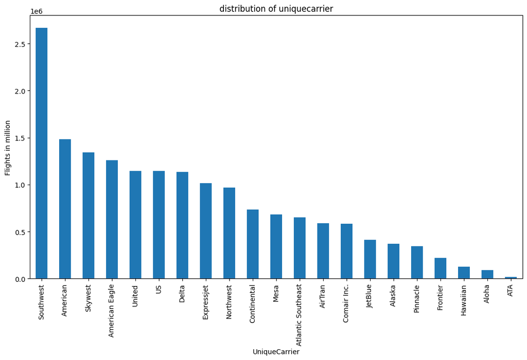

```python
#plot distribution of uniquecarrier
plt.figure(figsize=(13,7))
cleaned.uniquecarrier.value_counts().plot(kind = 'bar')
plt.title('distribution of uniquecarrier')
plt.ylabel('Flights in million')
plt.xlabel('UniqueCarrier')
```

i made this plot see which uniquecarrier is mostly used, i discovered Southwest was the highest number of flights followed by American and Skywest

### Distribution of Flight by Years

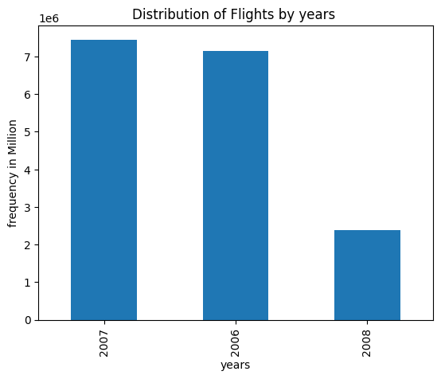

```python
#plot distribution of years using  value count
cleaned.year.value_counts().plot(kind= 'bar')
plt.title('Distribution of Flights by years ')
plt.xlabel('years')
plt.ylabel('frequency in Million')
```

This plot shows year 2008 had lower flight, i want to To investigate the drop in flight year 2008, i will queried the dataset below and find my answer. it also shows that year 2007 has the highest flight recorded.

```python
#used query to filter only months
abs = cleaned.query('year == 2008')
abs.month.value_counts()
```

```
3    616090
1    605765
4    598126
2    569236
Name: month, dtype: int64
```

After qeurying the year column in the dataset, i observe year 2008 had only 4 months recorded.

### Discuss the distribution(s) of your variable(s) of interest. Were there any unusual points? Did you need to perform any transformations?

> My variable of interest was CarrierDelay, UniqueCarriers, Day of the week, Cancellation Code and years distribution . I didnt perform any Transformation

### Of the features you investigated, were there any unusual distributions? Did you perform any operations on the data to tidy, adjust, or change the form of the data? If so, why did you do this?

> The Annual distribution for flight usage had only 4 months recorded in year 2008 which reduced observation by 68%. i used numpy to change the abbrevations in uniquecarrier, dayofweek and cancellation code

## Bivariate Exploration

#### What is The Distribution of Cancellation Code from 2006 to 2008?

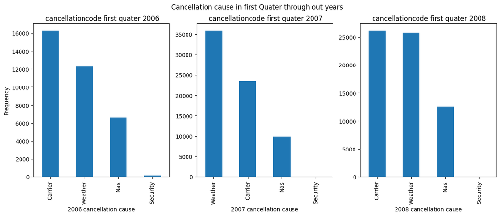

```python
#used query method to filter dataset for year , cancellation and just the first quater

cancellation_2006 = cleaned.query('year == 2006 & month <=4')
cancellation_2007 = cleaned.query('year == 2007 & month <=4')
cancellation_2008 = cleaned.query('year == 2008 & month <=4')


plt.figure(figsize=(15,5))
plt.subplot(1,3,1)


#bar plot of cancellation cause in 2006
cancellation_2006.cancellationcode.value_counts().plot(kind='bar')
plt.xlabel('2006 cancellation cause')
plt.ylabel('Frequency')
plt.title(' cancellationcode first quater 2006')


plt.subplot(1,3,2)
#bar plot of cancellation cause in 2007
cancellation_2007.cancellationcode.value_counts().plot(kind='bar')
plt.xlabel('2007 cancellation cause')
plt.title(' cancellationcode first quater 2007')



plt.subplot(1,3,3)
#bar plot of cancellation cause in 2008
cancellation_2008.cancellationcode.value_counts().plot(kind='bar')
plt.xlabel('2008 cancellation cause')
plt.title(' cancellationcode first quater 2008')
plt.suptitle('Cancellation cause in first Quater through out years');
```

## How weather affected Flight cancellation?

```python
#group the weather delay in time into 5 and create new column
cleaned_cancel.loc[cleaned_cancel['weatherdelay'] <=15, 'weather_cat'] = 1
cleaned_cancel.loc[cleaned_cancel['weatherdelay'] >=15, 'weather_cat'] = 2
cleaned_cancel.loc[cleaned_cancel['weatherdelay'] >=60, 'weather_cat'] = 3
cleaned_cancel.loc[cleaned_cancel['weatherdelay'] >=120, 'weather_cat'] = 4
cleaned_cancel.loc[cleaned_cancel['weatherdelay'] >180, 'weather_cat'] = 5
cleaned_cancel.loc[cleaned_cancel['weatherdelay'].isna(), 'weather_cat'] =0
```

```python
#group the weather delay in category that is associated to cancelled flight and assign to a new variable weather count
weather_count = cleaned_cancel.groupby(['weather_cat','cancelled'])['weather_cat'].size()
weather_count
```

```
weather_cat  cancelled
0.0          1             64442
1.0          1            282682
Name: weather_cat, dtype: int64
```

#### Recall 0.0 means 'NAN' and 1.0 means less than 15 mins

```python
#taking percentage
weather_count =  weather_count.reset_index(name='count')
weather_count['count_percentage'] = round((weather_count['count']/weather_count['count'].sum())*100,2)
```

```python
#show result
weather_count
```

|  | weather_cat | cancelled | count | count_percentage |
| --- | --- | --- | --- | --- |
| 0 | 0.0 | 1 | 64442 | 18.56 |
| 1 | 1.0 | 1 | 282682 | 81.44 |

```python
#percentage of cancelled flight from total
cancel_percent = round((weather_count['count'].sum()/cleaned.shape[0])*100,2)
```

```python
#replacing 0 and 1 with not_cancelled and cancelled respectively
weather_count['cancelled'] = weather_count.cancelled.replace({0:'not_Cancelled',1:'cancelled'})
```

```python
#replacing number with more meaningfull name
weather_count.weather_cat = weather_count.weather_cat.replace({0.0:'NaN',1.0:' <= 15mins',2.0:'>=15mins',3.0:'>=60mins',4.0:'>=120mins',5.0:'>180mins'})
```

```python
#displaying weather_count table
weather_count
```

|  | weather_cat | cancelled | count | count_percentage |
| --- | --- | --- | --- | --- |
| 0 | NaN | cancelled | 64442 | 18.56 |
| 1 | <= 15mins | cancelled | 282682 | 81.44 |

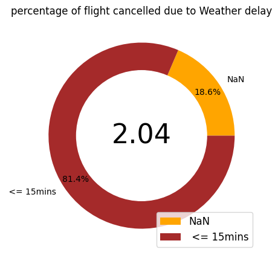

```python
#plot showing the cancelled flight due to weather delay
label =  weather_count.weather_cat
plt.figure(figsize=(5,5))
plt.pie(weather_count.count_percentage,colors=['orange','brown'],labels=(label.values),autopct='%1.1f%%',pctdistance=.85)
plt.title('percentage of flight cancelled due to Weather delay',color='black')
circle = plt.Circle((0, 0), 0.7, color='white')
sum_ = weather_count.count_percentage.sum()
fig = plt.gcf()
plt.text(0., 0., cancel_percent, horizontalalignment='center', verticalalignment='center',fontsize=32)
fig.gca().add_artist(circle)
plt.rc('font', size=12)
plt.legend(loc=4)
;
plt.show();
```

## Flights delayed due to weather?

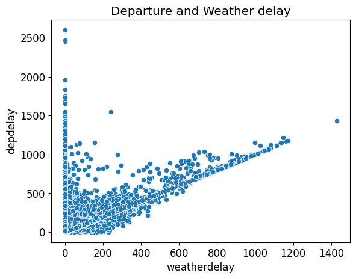

```python
sns.scatterplot(data= cleaned_delay, x='weatherdelay',y='depdelay')
plt.title('Departure and Weather delay');
```

### Day of the week that is likely for a flight to be cancelled

```python
# replacing integer to readable column from only cancelled flight
cleaned_cancel.dayofweek = cleaned_cancel.dayofweek.replace({1:'Monday',2:'Tuesday',3:'Wednesday',4:'Thursday',5:'Friday',6:'Saturday',7:'Sunday'})
```

```python
#group dayofweek and cancelled
daypivot = cleaned_cancel.groupby(['dayofweek','cancelled']).size()
dayfreq = daypivot.copy()
```

```python
#assign only index to daypivot
daypivot = daypivot.index.levels[0]
#assign values to dayfreq
dayfreq = dayfreq.values

#assign values to dayfreq
dayfreq
```

```
array([57297, 49379, 33508, 42661, 55849, 53353, 55077], dtype=int64)
```

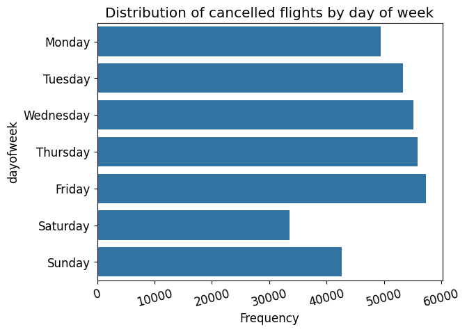

```python
#create a label of day of the week
label = ['Monday','Tuesday','Wednesday','Thursday','Friday','Saturday','Sunday']
#create a barplot
sns.barplot(y=daypivot, x=dayfreq,color=base_color,order=label)
plt.xticks(rotation=15)
plt.xlabel('Frequency')
plt.title('Distribution of cancelled flights by day of week');
```

This plot is to show Flights During the dayofweek that had more cancellation and it appears weekend(saturday, sunday) had less cancellation, while friday had higher cancellation.

### Distribution of flight delay and day of the week.

```python
# replacing integer to readable column from only delayed flight
cleaned_delay.dayofweek = cleaned_delay.dayofweek.replace({1:'Monday',2:'Tuesday',3:'Wednesday',4:'Thursday',5:'Friday',6:'Saturday',7:'Sunday'})
```

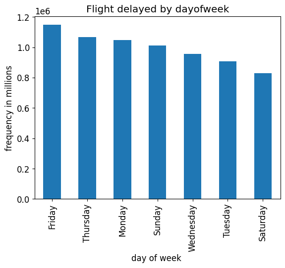

```python
# make a plot of flights delay by dayofweek
cleaned_delay.dayofweek.value_counts().plot(kind='bar')
plt.title('Flight delayed by dayofweek')
plt.ylabel('frequency in millions')
plt.xlabel('day of week ')
```

This plot is to show Flights During the dayofweek that had more delay and it appears weekend(saturday) had less delay, while friday experienced high delay with no much differnce accross the week.

### Which Carrier experienced high flight cancellation?

```python
#value count of uniquecarriers and assigning to variable called carrier_Value
carrier_delay = cleaned_cancel.uniquecarrier.value_counts()
carrier_value = carrier_delay.values
carrier_value
```

```
array([51742, 38835, 33803, 26783, 25981, 24441, 23324, 18344, 18049,
       17267, 16843, 14075, 12036,  5797,  5684,  5446,  5271,  1398,
        1175,   603,   227], dtype=int64)
```

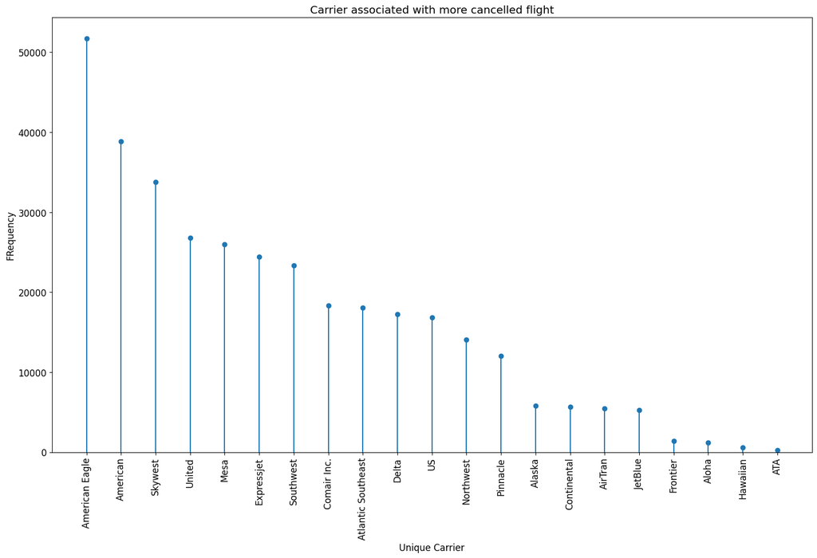

```python
#plot carrier associated with more cancelled flight

#create a function to plot distribution of delayed and cancelled flight by uniquecarrier
def count_plot(x,y,z):
    fig,axes = plt.subplots(figsize=(15,10))
    #make a stem plot
    axes.stem(x,y, use_line_collection=True, basefmt=' ')
    # starting value of y-axis
    axes.set_ylim(0)
    plt.xticks(rotation = 90);
    plt.tight_layout()
    plt.title('Carrier associated with more  cancelled flight')
    plt.xlabel('Unique Carrier')
    plt.ylabel('FRequency');
    plt.title('Carrier associated with more {} flight'.format(z))
count_plot(carrier_delay.index,carrier_value,'cancelled')
```

#### the above plot is to show The Airline who had more flight cancellation, it Appears American Eagle has the highest flight cancellation through out the 3 years

## which Airline has more depature delay time ?

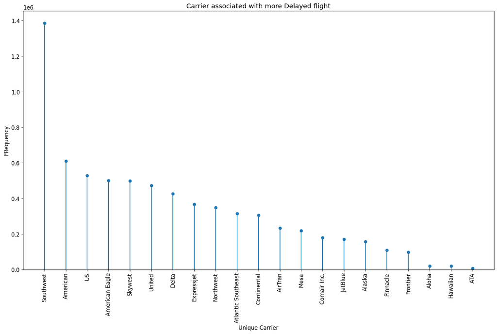

```python
#value count of uniquecarriers and assigning to variable called carrier_Value
carrier_delay_2 = cleaned_delay.uniquecarrier.value_counts()
carrier_value_2 = carrier_delay_2.values
count_plot(carrier_delay_2.index,carrier_value_2,'Delayed')
```

### What destination City are prone to Flight Cancellation?

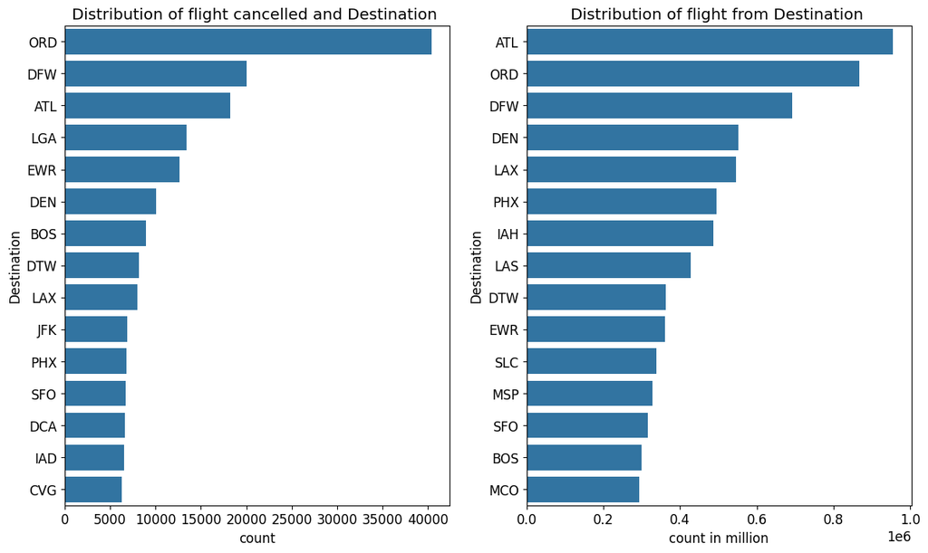

```python
#use cancelled rows to search for destination that are prone to flight cancellation
cleaned_dest = cleaned_cancel.dest.value_counts().head(15)
dest_valu = cleaned_dest.values


#plot a barplot of the distribution above
plt.figure(figsize=(14,8))
plt.subplot(1,2,1)
sns.barplot(y=cleaned_dest.index , x=dest_valu,color=base_color)
plt.title('Distribution of flight cancelled and Destination ')
plt.ylabel('Destination')
plt.xlabel('count');

#frequency of most origin destination
cleaned_dest_1 = cleaned.dest.value_counts().head(15)
dest_valu_1 = cleaned_dest_1.values
#plot the distribution of flight from destination
plt.subplot(1,2,2)
sns.barplot(y=cleaned_dest_1.index , x=dest_valu_1, color=base_color)
plt.title('Distribution of flight from Destination ')
plt.ylabel('Destination')
plt.xlabel('count in million');
```

The left hand plot shows the destination with high cancellation and ORD was the highest. The right hand plot shows the destination with the highest record flight in total and ATL has the highest destination.

### Which Origin experienced more Flight Cancellation?

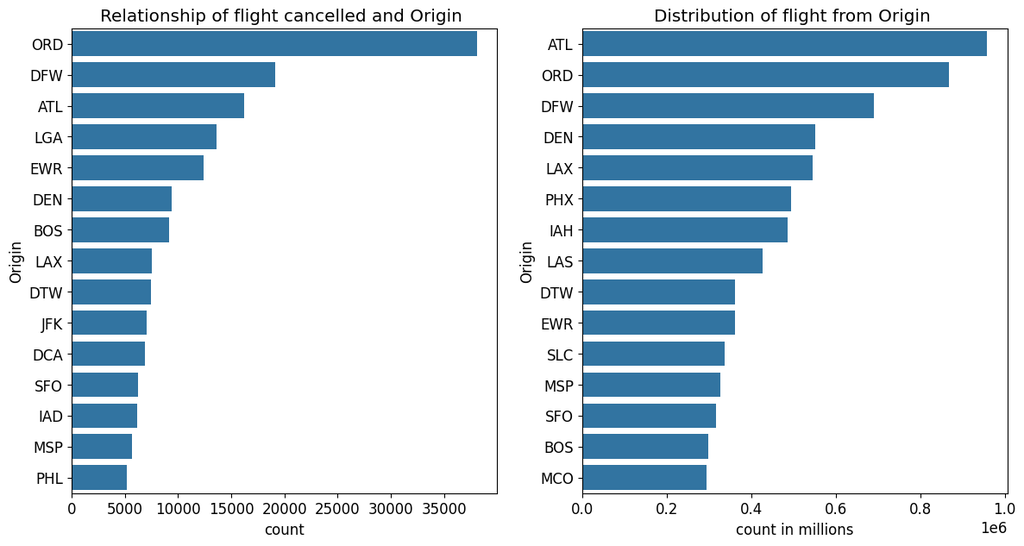

```python
#use cancelled rows to search for destination that are prone to flight cancellation
cleaned_origin = cleaned_cancel.origin.value_counts().head(15)
origin_valu = cleaned_origin.values
cleaned_dest

plt.figure(figsize=(14,7))

#plot a barplot of the distribution above
plt.subplot(1,2,1)
sns.barplot(y=cleaned_origin.index , x=origin_valu,color=base_color)
plt.title('Relationship of flight cancelled and Origin ')
plt.ylabel('Origin')
plt.xlabel('count');


#frequency of most origin destination
cleaned_origin_2 = cleaned.origin.value_counts().head(15)
origin_valu_2 = cleaned_origin_2.values

plt.subplot(1,2,2)
sns.barplot(y=cleaned_origin_2.index , x=origin_valu_2,color=base_color)
plt.title('Distribution of flight from Origin ')
plt.ylabel('Origin')
plt.xlabel('count in millions');
```

> The left hand plot shows the origin with high cancellation and ORD was the highest. The right hand plot shows the origin with the highest record flight in total and ATL has the highest origin.

## What is the frequency of flight cancelled or delayed by scheduledtime

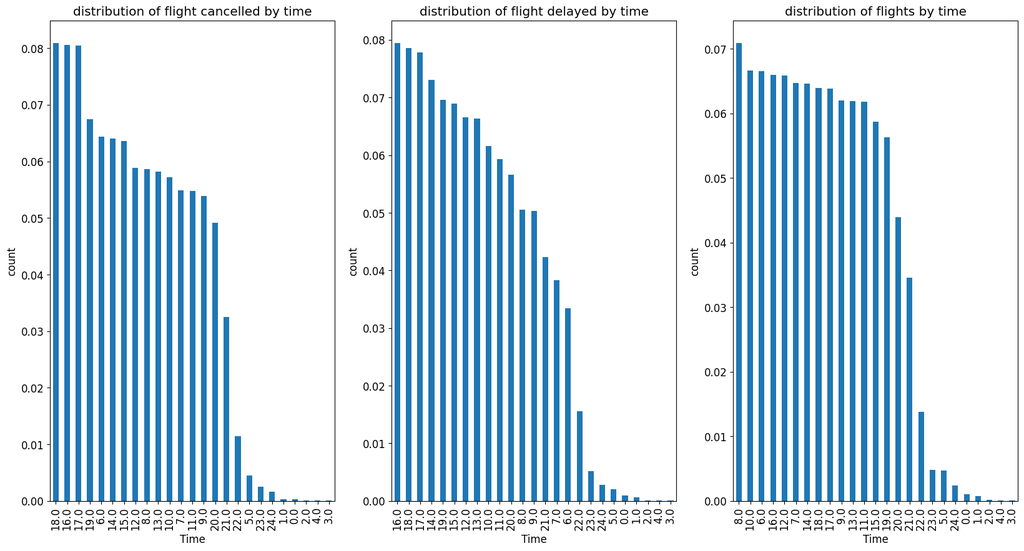

```python
#plot frequency of flight occurence by time
Schedhours= round((cleaned_cancel.crsdeptime/100),0)
Schedhours_1 = round((cleaned_delay.crsdeptime/100),0)
Schedhours_2 = round((cleaned.crsdeptime/100),0)

#plot frequency of flight cancelled by time
plt.figure(figsize=(20,10))
plt.subplot(1,3,1)
Schedhours.value_counts(10).plot(kind='bar')
plt.title('distribution of flight cancelled by time')
plt.xlabel('Time')
plt.ylabel('count');

#plot frequency of flight delayed by time
plt.subplot(1,3,2)
Schedhours_1.value_counts(10).plot(kind='bar')
plt.title('distribution of flight delayed by time')
plt.xlabel('Time')
plt.ylabel('count');

#plot frequency of flight  by time
plt.subplot(1,3,3)
Schedhours_2.value_counts(10).plot(kind='bar')
plt.title('distribution of flights by time')
plt.xlabel('Time')
plt.ylabel('count');
```

### Did you observe any interesting relationships between the other features (not the main feature(s) of interest)?

> No

## Relationship between Depature Delay or Cancellation ,Scheduled Flight by Day of weeK?

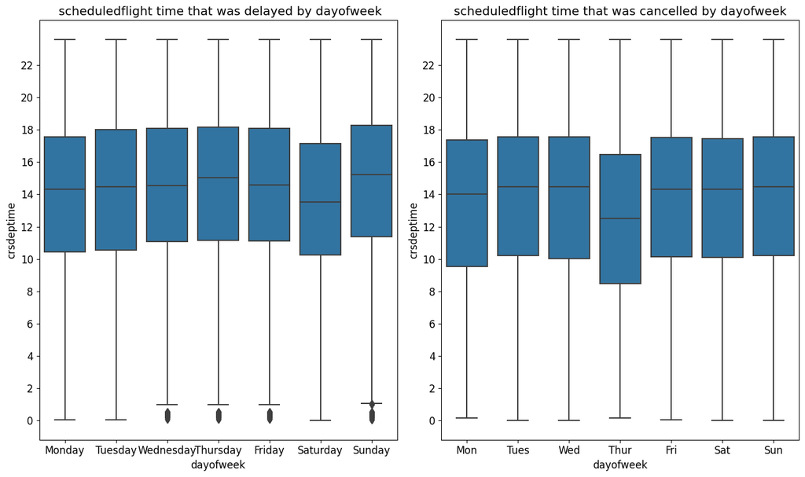

```python
#plot Distribution of schedflight time that was delayed by dayofweek'
plt.figure(figsize=(20,8))
plt.subplot(1,3,1);
Schedhours = cleaned_delay.crsdeptime/100

sns.boxplot(y= Schedhours, x='dayofweek' ,data= cleaned_delay,color= base_color, order=['Monday','Tuesday','Wednesday','Thursday','Friday','Saturday','Sunday'])
plt.yticks(np.arange(0,24,2))
plt.title(' scheduledflight time that was delayed by dayofweek')
plt.tight_layout();

#plot scheduledflight time that was cancelled by dayofweek
plt.subplot(1,3,2);
Schedhours = cleaned_cancel.crsdeptime/100
sns.boxplot(y= Schedhours, x='dayofweek' ,data= cleaned_cancel,color= base_color)
plt.yticks(np.arange(0,24,2))
plt.xticks([0,1,2,3,4,5,6],['Mon','Tues','Wed','Thur','Fri','Sat','Sun'])
plt.title('scheduledflight time that was cancelled by dayofweek')
plt.tight_layout();
```

### Were there any interesting or surprising interactions between features?

- Friday has high cancellations and delays.

## Conclusions

- SouthWest Airlines Carrier operates high number of flights in U.S. with less cancellations but high delay while America Eagle had more cancellation
- ORD destination had the highest record flight cancellation and ATL has the highest Origin

```python
from subprocess import call
call(['python', '-m', 'nbconvert', 'exploration_template.ipynb'])
```

```
0
```

```python
#saving Dataframe to csv file
cleaned.to_csv('cleaned.csv')
cleaned_delay.to_csv('cleaned_delay.csv')
cleaned_cancel.to_csv('cleaned_cancel.csv')
```